# 16S_vegan_tutorial

## 4. BETA DIVERSITY

Compare all the samples to one another, how similar or different are the species and their abundances between sites.

The general goal is to plot the distances between samples using different ordination methods (NMDS, PCoA, PCA, CA). Some methods also allow you to fit the environmental variables to your data and find which properties explain better the distribution patterns you see (NMDS, RDA, CCA).

There are many choices to make, since the underlying assumptions and the information that each method provides is different. You can find information on each method here: https://mb3is.megx.net/gustame

We will show examples of NMDS and CCA, but keep in mind that there are more oprtions.

### 4.1 Preparing data

#### 4.1.2 Log transform OTU data

```r
# Use log10(x+1) because we can have 0 values in our count data
logOTUt_rarefy_nozero <- log10(OTUt_rarefy_nozero + 1)
```

### 4.1.2 Scale continuous data

```r
# Normalize environmental data with z-scores
# z score = (Value - Mean)/SD
metadata_scale <-as.data.frame(scale(metadata[-1])) # only continuous variables
metadata_scale_all <- cbind(habitat=metadata$habitat,metadata_scale) # add the habitat column
```

### 4.1.3 Calculate a distance matrix

```r
# Calculate a distance matrix: default uses Bray Curtis distances, but there are many many more! Check ?vegdist() methods
# Make sure you are using the transposed table (rows as samples)
logOTUt_rarefy_nozero_BC <- vegdist(logOTUt_rarefy_nozero, method="bray")
```

### 4.2. NMDS (Non-metric multidimensional scaling)

#### 4.2.1 NMDS

NMDS is based on a distance matrix, but it is calculated inside the function.

```r
set.seed(100)
# The distance matrix is calculated inside the function, so we just provide the raw data
logOTUt.nmds <- metaMDS(logOTUt_rarefy_nozero, distance="bray")
#get the stress
logOTUt.nmds$stress # 0.035
logOTUt.nmds$points
```

#### 4.2.2 Plot Base NMDS

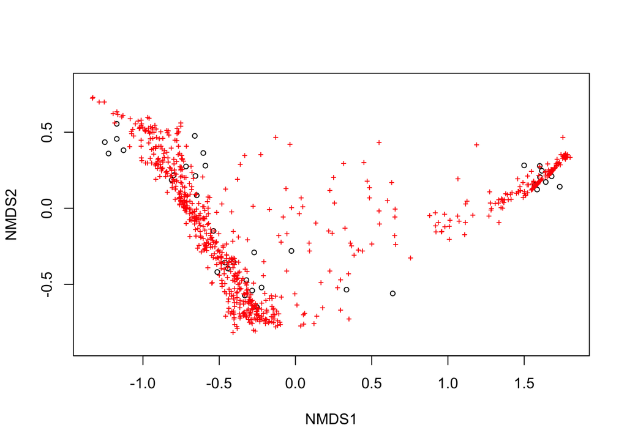

```r
# Plot the NMDS
plot(logOTUt.nmds) # Circles are the samples (called "sites"), and crosses are the OTUs ("species")
```

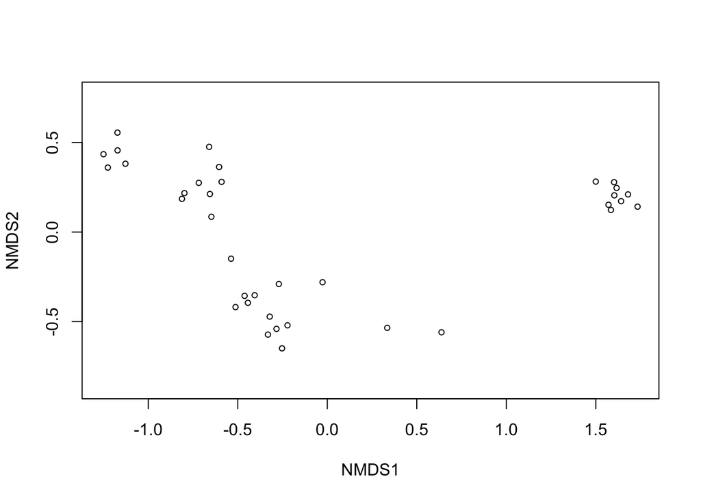

```r
plot(logOTUt.nmds,display="sites") # Only the sample distribution
```

#### 4.2.3 Continuous environmebtal variables

```r
##Check best explanatory variables (No NAs)
bioenv(logOTUt_rarefy_nozero,metadata_scale)
```

```
##
## Call:
## bioenv(comm = logOTUt_rarefy_nozero, env = metadata_scale)
##
## Subset of environmental variables with best correlation to community data.
##
## Correlations:    spearman
## Dissimilarities: bray
## Metric:          euclidean
##
## Best model has 2 parameters (max. 5 allowed):
## DOCuM Temp
## with correlation  0.705258
```

```r
# Overlay environmental variables on nmds plot
# Envfit admints categorical variables
logOTUt.env <- envfit(logOTUt.nmds,metadata_scale_all,permu=999,na.rm=TRUE)
logOTUt.env
```

```
##
## ***VECTORS
##
##          NMDS1    NMDS2     r2 Pr(>r)
## DOCuM -0.96937  0.24559 0.8826  0.001 ***
## TDNuM -0.06304 -0.99801 0.0722  0.307
## Temp  -0.09387  0.99558 0.6433  0.001 ***
## Sal    0.59244 -0.80561 0.4434  0.001 ***
## pH     0.17970 -0.98372 0.4925  0.001 ***
## ---
## Signif. codes:  0 '***' 0.001 '**' 0.01 '*' 0.05 '.' 0.1 ' ' 1
## Permutation: free
## Number of permutations: 999
##
## ***FACTORS:
##
## Centroids:
##                   NMDS1   NMDS2
## habitatCoral    -0.1305 -0.4095
## habitatMangrove -0.9928  0.3711
## habitatSeagrass -0.4913 -0.1629
## habitatSand      1.6063  0.2001
##
## Goodness of fit:
##             r2 Pr(>r)
## habitat 0.9111  0.001 ***
## ---
## Signif. codes:  0 '***' 0.001 '**' 0.01 '*' 0.05 '.' 0.1 ' ' 1
## Permutation: free
## Number of permutations: 999
##
## 1 observation deleted due to missingness
```

```r
### Get only the continuous ones that are significant (for the ggplot later)
logOTUt.env.sel <- envfit(logOTUt.nmds,metadata_scale[-2],permu=999,na.rm=TRUE)
```

#### 4.2.4 Categorical environmental variables

```r
# You will need the package pairwiseAdonis for the comparisons
#library(devtools)
#install_github("pmartinezarbizu/pairwiseAdonis/pairwiseAdonis")
#library(pairwiseAdonis)

# Check signinificant grouping variable with the PERMANOVA test adonis
# You can supply the distance matrix or it will calculate the Bray-Curtis by default
adonis(logOTUt_rarefy_nozero  ~ metadata$habitat) ### Check if habitat is a significant grouping variable
```

```
##
## Call:
## adonis(formula = logOTUt_rarefy_nozero ~ metadata$habitat)
##
## Permutation: free
## Number of permutations: 999
##
## Terms added sequentially (first to last)
##
##                  Df SumsOfSqs MeanSqs F.Model      R2 Pr(>F)
## metadata$habitat  3    6.3682 2.12275  46.926 0.81479  0.001 ***
## Residuals        32    1.4475 0.04524         0.18521
## Total            35    7.8158                 1.00000
## ---
## Signif. codes:  0 '***' 0.001 '**' 0.01 '*' 0.05 '.' 0.1 ' ' 1
```

```r
# Compare habitats 2 by 2
pairwise.adonis(logOTUt_rarefy_nozero,metadata$habitat)
```

```
##                  pairs Df SumsOfSqs    F.Model        R2 p.value
## 1 Mangrove vs Seagrass  1 0.6092968  11.517342 0.4185485   0.001
## 2    Mangrove vs Coral  1 1.3905611  23.103584 0.5908303   0.001
## 3     Mangrove vs Sand  1 3.9034145 156.510923 0.9072522   0.001
## 4    Seagrass vs Coral  1 0.2387980   3.644015 0.1855026   0.026
## 5     Seagrass vs Sand  1 3.6067769 119.099774 0.8815690   0.001
## 6        Coral vs Sand  1 2.9876311  79.523379 0.8325017   0.001
##   p.adjusted sig
## 1      0.006   *
## 2      0.006   *
## 3      0.006   *
## 4      0.156
## 5      0.006   *
## 6      0.006   *
```

#### 4.2.5 Plot NMDS colored by habitat and with metadata fit

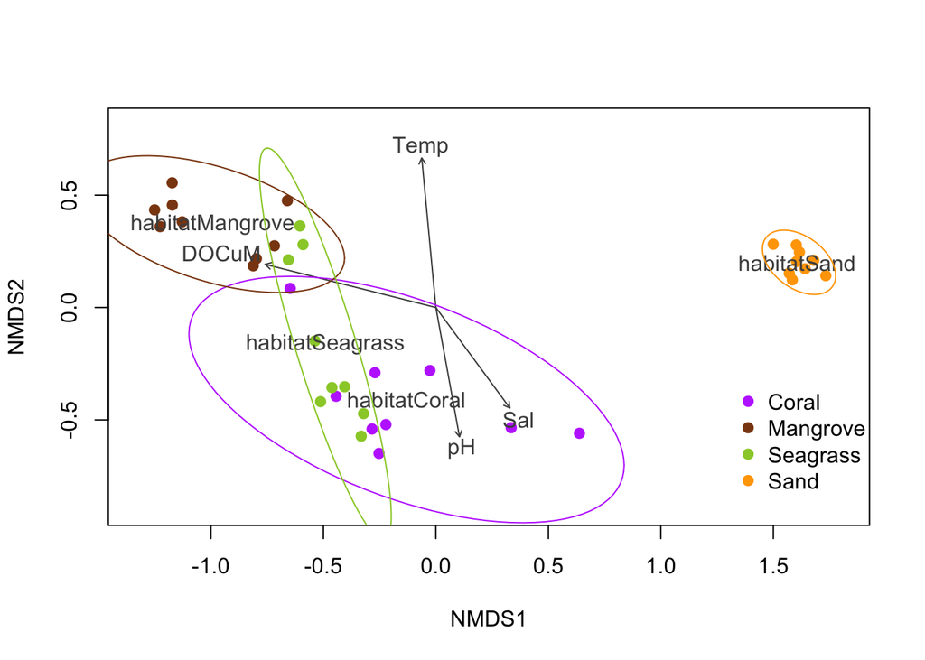

```r
# Make plot nicer, by coloring the samples accoriding to depth habitat
mds.fig <- ordiplot(logOTUt.nmds, type = "none")
# plot just the samples, colour by habitat, pch=19 means plot a circle
points(mds.fig, "sites", pch = 19, col = "darkorchid1", select = metadata$habitat == "Coral")
points(mds.fig, "sites", pch = 19, col = "yellowgreen", select = metadata$habitat == "Seagrass")
points(mds.fig, "sites", pch = 19, col = "chocolate4", select = metadata$habitat == "Mangrove")
points(mds.fig, "sites", pch = 19, col = "orange", select = metadata$habitat == "Sand")
legend(x=1.3,y=-0.3, col=c("darkorchid1","chocolate4","yellowgreen","orange"),legend=c("Coral","Mangrove","Seagrass","Sand"),pch=19, bty="n")

### Overlay significant environmental variables
plot(logOTUt.env, col = "gray30",p.max=0.05) ### select the p val of the samples you plot

## add 95% CI ellipse
ordiellipse(logOTUt.nmds, metadata$habitat, conf = 0.95, label = FALSE,col=c("darkorchid1","chocolate4","yellowgreen","orange"))
```

#### 4.2.6 Plot ggplot NMDS

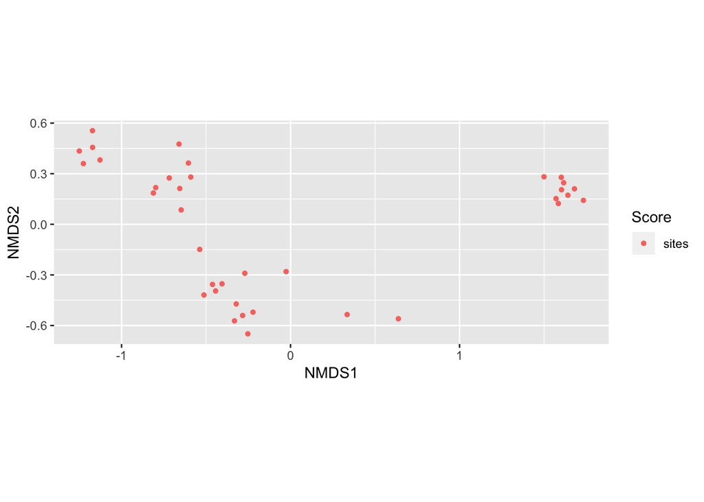

```r
autoplot(logOTUt.nmds, layers = "sites") ### Like the basic plot we did in base
```

##### NMDS with color according to habitat

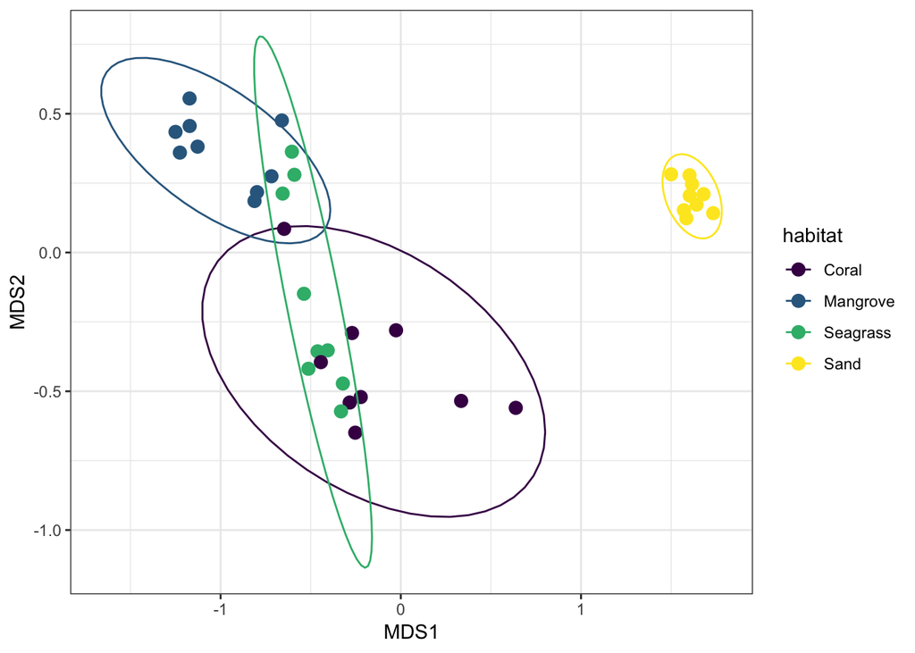

```r
# We need to rearrange the data from the OTUt.nmds object
# str(OTUt.nmds)

# Recover the values form the NMDS output object
nmds.p <- as.data.frame(logOTUt.nmds$points)
# Rover the environmental fit arrows (only the significant ones, check in 4.2.3)
envFort <- fortify(logOTUt.env.sel)

# Combine the NMDS and metadata in one table
# Only do this if your samples are in the same order in the NMDS and metadata
# row.names(logOTUt.nmds$points)==row.names(metadata) #Check!
nmds.p.m <- cbind(nmds.p,metadata)

# reorder the levels of habitat
nmds.p.m$habitat <- ordered(nmds.p.m$habitat,levels=c("Coral","Mangrove","Seagrass","Sand"))

# Make a ggplot
nmds.ggplot <- ggplot(nmds.p.m, aes(x = MDS1, y = MDS2,color= habitat))+
  geom_point(size = 3)+
  stat_ellipse(level = 0.95)+
  #scale_color_manual(values=c("darkorchid1","chocolate4","yellowgreen","orange"))+
  theme_bw()

# see the plot
nmds.ggplot
```

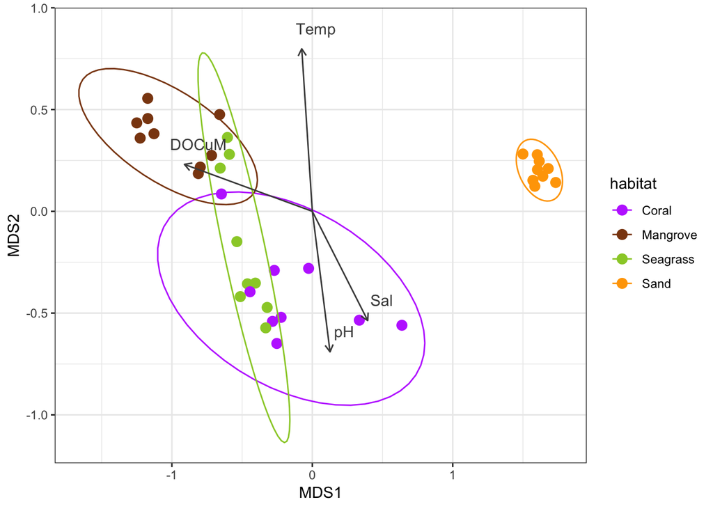

```r
# Make a ggplot with environmental variables overlayed
nmds.ggplot.env <- ggplot(nmds.p.m)+
  geom_point(size = 3,
             aes(x = MDS1, y = MDS2,color= habitat))+
  stat_ellipse(level = 0.95,aes(x = MDS1, y = MDS2,color= habitat))+
  scale_color_manual(values=c("darkorchid1","chocolate4","yellowgreen","orange"))+
  geom_segment(data=envFort,aes(x=0,xend=NMDS1,y=0,yend=NMDS2),arrow=arrow(length=unit(0.2,"cm")),col=colors()[290])+
  geom_text(data=envFort,aes(x=NMDS1,y=NMDS2,label=Label),nudge_x=0.1,nudge_y=0.1,color=colors()[290])+
  theme_bw()

# see the plot
nmds.ggplot.env
```

### 4.3 CCA (Constrained Canonical correspondence analysis).

Constrained means that we use the environmental properties to explain (constrain) the variancce in the dataset.

CCA uses Chi-squared distances and is appropriate for count data.

We need the OTUt table (not the distance matrix) and the metadata without NAs.

### 4.3.1 NA values in the metadata

What to do if we have NAs? We have two options: we remove the variables that have NAs or we try to fill in the values (given that the variation in the data is not too big) and that we don’y have many NAs. We can try and fill with mean or interpolate if the variable has a predictable distribution.

```r
# Check if the rows have all the data
complete.cases(metadata_scale) # row 8 has missing value
```

```
##  [1]  TRUE  TRUE  TRUE  TRUE  TRUE  TRUE  TRUE FALSE  TRUE  TRUE  TRUE
## [12]  TRUE  TRUE  TRUE  TRUE  TRUE  TRUE  TRUE  TRUE  TRUE  TRUE  TRUE
## [23]  TRUE  TRUE  TRUE  TRUE  TRUE  TRUE  TRUE  TRUE  TRUE  TRUE  TRUE
## [34]  TRUE  TRUE  TRUE
```

```r
is.na(metadata_scale[8,]) # St02_SD in the DOCuM column
```

```
##         DOCuM TDNuM  Temp   Sal    pH
## St02_SD  TRUE FALSE FALSE FALSE FALSE
```

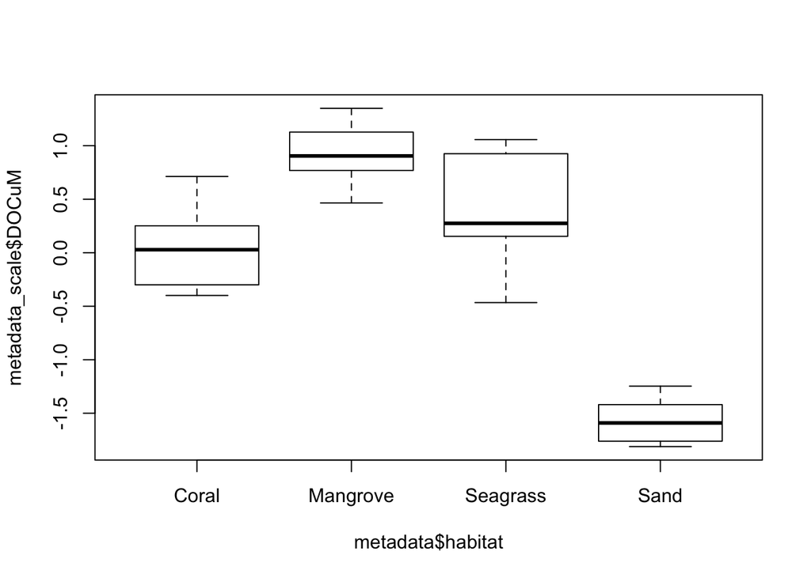

```r
# fill NA with mean value
plot(metadata_scale$DOCuM ~ metadata$habitat) # Look at the variance of the variable in each habitat. Sand (SD) habitat has low variance, safe to fill with mean
```

```r
mean(metadata_scale[metadata$habitat=="Sand",]$DOCuM,na.rm=TRUE) # MEAN = -1.57
```

```
## [1] -1.57509
```

```r
sd(metadata_scale[metadata$habitat=="Sand",]$DOCuM,na.rm=TRUE) # SD = 0.21
```

```
## [1] 0.2093143
```

```r
metadata_scale[which(is.na(metadata_scale$DOCuM)==TRUE),]$DOCuM <- mean(metadata_scale[metadata$habitat=="Sand",]$DOCuM,na.rm=TRUE) # replace NA with mean value

complete.cases(metadata_scale) # all complete now
```

```
##  [1] TRUE TRUE TRUE TRUE TRUE TRUE TRUE TRUE TRUE TRUE TRUE TRUE TRUE TRUE
## [15] TRUE TRUE TRUE TRUE TRUE TRUE TRUE TRUE TRUE TRUE TRUE TRUE TRUE TRUE
## [29] TRUE TRUE TRUE TRUE TRUE TRUE TRUE TRUE
```

#### 4.3.2 Model comparison

We are going to do an automated process to determine which variables contribute to the data distribution.

We will start calculating a null model (distribution without any environmental variables)

Then we will calculate a full model (with all the environmental variables)

Then we will go from the null model to the full model by adding an environmental variable in each step. We will keep the model that has that explains the highest variance with the minimum number of significant variables.

##### - Null model. No constraints

```r
# No constraints: CCA (No environmental variables)
mod0 <- cca(logOTUt_rarefy_nozero ~ 1, metadata_scale, na.action = "na.omit")
mod0 # Check the variance. All the Variance (Inertia) is Unconstrained
```

```
## Call: cca(formula = logOTUt_rarefy_nozero ~ 1, data =
## metadata_scale, na.action = "na.omit")
##
##               Inertia Rank
## Total           1.643
## Unconstrained   1.643   35
## Inertia is scaled Chi-square
##
## Eigenvalues for unconstrained axes:
##    CA1    CA2    CA3    CA4    CA5    CA6    CA7    CA8
## 0.8415 0.3445 0.1056 0.0831 0.0314 0.0239 0.0201 0.0180
## (Showing 8 of 35 unconstrained eigenvalues)
```

```r
anova(mod0) # There is no model, all the variance is residual variance
```

```
## No constrained component
##
## Model: cca(formula = logOTUt_rarefy_nozero ~ 1, data = metadata_scale, na.action = "na.omit")
##          Df ChiSquare  F Pr(>F)
## Model     0    0.0000  0
## Residual 35    1.6431
```

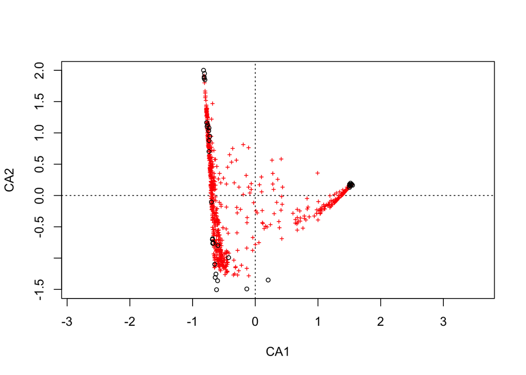

```r
plot(mod0) # base plot
```

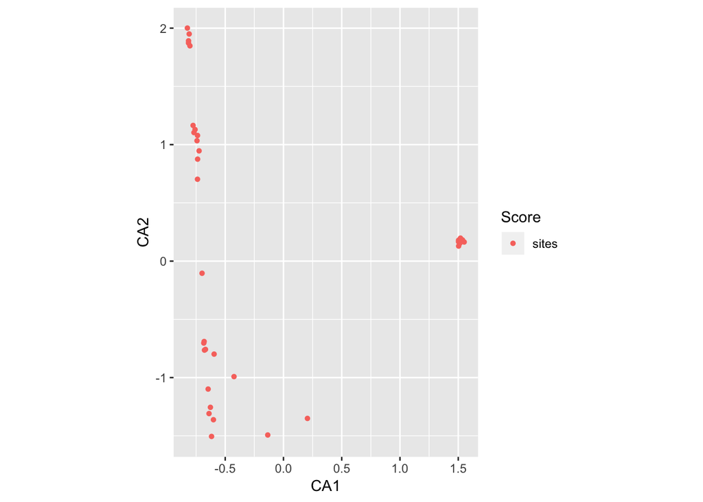

```r
autoplot(mod0, layers = c("sites", "biplot")) # ggplot
```